# Practicum2

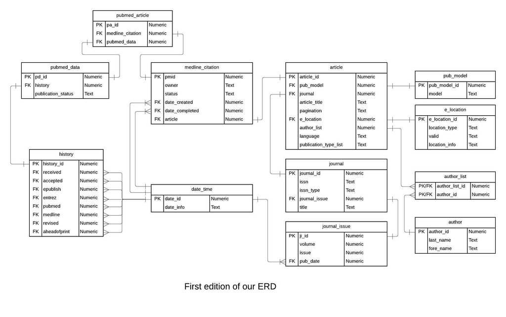

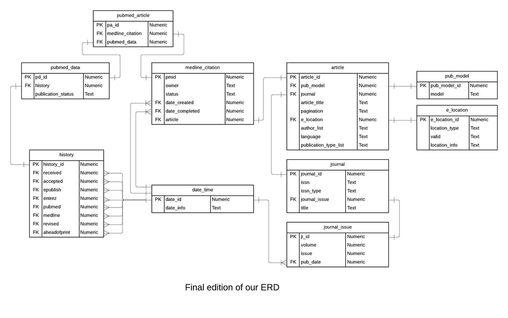

## Note: originally, we had a junction table article_author to reflect the relationship between an article and an author. But as we proceed we realize that in our design we only care about the names of the authors, so we decided to put all the authors of an article as a text, with a ‘;’ as the separator.We later can conveniently just split the text and retrieve every author for data consumption.

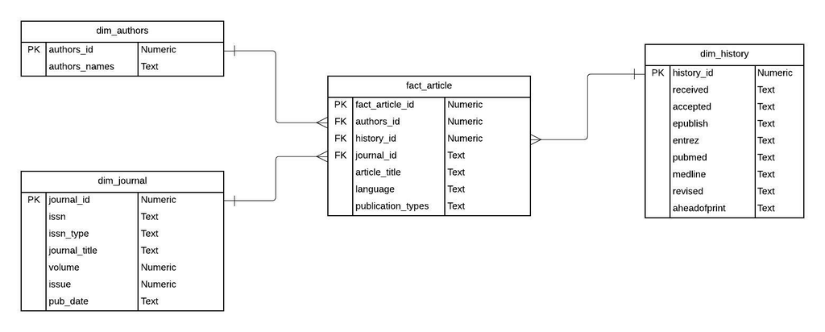

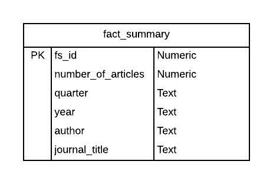

## ****************Connect to database*******************

```r
library(DBI)
library(sqldf)
dbcon <- dbConnect(odbc::odbc(),
                .connection_string = "Driver={MySQL ODBC 8.0 Unicode Driver};",
                Server = "localhost", Database = "practicum2", Uid = "root", PWD = 123456,
                Port = 3306)
```

## *******************Part 1 Load XML*********************

```r
library(XML)
path <- "C:/Practicum2"
filename <- "pubmed_sample.xml"
fpn = paste(path, filename,sep = "/")

xmlDom <- xmlParse(fpn)
xmlRoot <- xmlRoot(xmlDom)

# Get number of articles
numOfArticles <- xmlSize(xmlRoot)
```

## ******1.1 Create empty data frames*********

```r
# Create data frame for pubmed_article
pubmed_article.df <- data.frame(pa_id = vector(mode = "integer", length = numOfArticles),
                             medline_citation = vector(mode = "integer", length = numOfArticles),
                             pubmed_data = vector(mode = "integer", length = numOfArticles),
                             stringsAsFactors = F)

# Create data frame for medline_citation
medline_citation.df <- data.frame(pmid = vector(mode = "integer", length = numOfArticles),
                               owner = vector(mode = "character", length = numOfArticles),
                               status = vector(mode = "character", length = numOfArticles),
                               date_created = vector(mode = "character", length = numOfArticles),
                               date_completed = vector(mode = "character", length = numOfArticles),
                               article = vector(mode = "integer", length = numOfArticles),
                               stringsAsFactors = F
                               )

# Create data frame for article
article.df <- data.frame(article_id = vector(mode = "integer", length = numOfArticles),
                      pub_model = vector(mode = "integer", length = numOfArticles),
                      journal = vector(mode = "integer", length = numOfArticles),
                      article_title = vector(mode = "character", length = numOfArticles),
                      pagination = vector(mode = "character", length = numOfArticles),
                      e_location = vector(mode = "integer", length = numOfArticles),
                      author_list = vector(mode = "character", length = numOfArticles),
                      language = vector(mode = "character", length = numOfArticles),
                      publication_type_list = vector(mode = "character", length = numOfArticles),
                      stringsAsFactors = F)

# Create data frame for pub_model
pub_model.df <- data.frame(pub_model_id = integer(),
                        model = character(),
                        stringsAsFactors = F)

# Create data frame for journal
journal.df <- data.frame(journal_id = integer(),
                         issn = character(),
                         issn_type = character(),
                         journal_issue = integer(),
                         title = character(),
                         stringsAsFactors = F)

# Create data frame for journal_issue
journal_issue.df <- data.frame(ji_id = integer(),
                      volume = character(),
                      issue = character(),
                      pub_date = integer(),
                      stringsAsFactors = F)

# Create data frame for e_location
e_location.df <- data.frame(e_location_id = integer(),
                         location_type = character(),
                         valid = character(),
                         location_info = character(),
                         stringsAsFactors = F)

# Create data frame for pubmed_data
pubmed_data.df <- data.frame(pd_id = vector(mode = "integer", length = numOfArticles),
                          history = vector(mode = "integer", length = numOfArticles),
                          publication_status = vector(mode = "character", length = numOfArticles),
                          stringsAsFactors = F)

# Create data frame for history
history.df <- data.frame(history_id = vector(mode = "integer", length = numOfArticles),
                         received = vector(mode = "character", length = numOfArticles),
                         accepted = vector(mode = "character", length = numOfArticles),
                         epublish = vector(mode = "character", length = numOfArticles),
                         entrez = vector(mode = "character", length = numOfArticles),
                         pubmed = vector(mode = "character", length = numOfArticles),
                         medline = vector(mode = "character", length = numOfArticles),
                         revised = vector(mode = "character", length = numOfArticles),
                         aheadofprint = vector(mode = "character", length = numOfArticles),
                         stringsAsFactors = F)

# Create data frame for date
date_time.df <- data.frame(date_id = integer(),
                      date_info = character(),
                      stringsAsFactors = F)
```

```r
# Parse a date node[1]
parseDate <- function (aDateNode)
{
  date_str <- ""
  year <- ""
  month <- ""
  day <- ""
  # Indicates a <MedlineDate> tag
  if(xmlSize(aDateNode) == 1){
    year <- substring(xmlValue(aDateNode[[1]]), 1, 4)
    month <- substring(xmlValue(aDateNode[[1]]), 6, 8)
  } else if (xmlSize(aDateNode) == 2) {
    year <- as.character(xmlValue(aDateNode[[1]]))
    month <- as.character(xmlValue(aDateNode[[2]]))
  } else if (xmlSize(aDateNode) == 3 || xmlSize(aDateNode) == 5) {
    year <- as.character(xmlValue(aDateNode[[1]]))
    month <- as.character(xmlValue(aDateNode[[2]]))
    day <- as.character(xmlValue(aDateNode[[3]]))
  }

  if (toupper(month) == "JAN") {
    month = "1"
  } else if (toupper(month) == "FEB") {
    month = "2"
  }else if (toupper(month) == "MAR") {
    month = "3"
  }else if (toupper(month) == "APR") {
    month = "4"
  }else if (toupper(month) == "MAY") {
    month = "5"
  }else if (toupper(month) == "JUN") {
    month = "6"
  }else if (toupper(month) == "JUL") {
    month = "7"
  }else if (toupper(month) == "AUG") {
    month = "8"
  }else if (toupper(month) == "SEP") {
    month = "9"
  }else if (toupper(month) == "OCT") {
    month = "10"
  }else if (toupper(month) == "NOV") {
    month = "11"
  }else if (toupper(month) == "DEC") {
    month = "12"
  }

  if (nchar(month) == 1) {
    month <- paste("0", month, sep = "")
  }
  if (day != "" && nchar(day) == 1) {
    day <- paste("0", day, sep = "")
  }

  if (day != "") {
    date_str <- paste(year, month, day, sep = "")
  } else {
    date_str <- paste(year, month, sep = "")
  }

  return (date_str)
}
```

## ***********1.2 Parse xml and populate data frames************

```r
for (i in 1:numOfArticles)
{
  # get current pubmed_article, medline_citation and pubmed_data nodes
  cur_pubmed_article <- xmlRoot[[i]]
  cur_medline_citation <- cur_pubmed_article[[1]]
  cur_pubmed_data <- cur_pubmed_article[[2]]

  # article
  cur_article <- xmlElementsByTagName(cur_medline_citation, "Article", recursive = FALSE)[[1]]

  # -- article_id

  article.df$article_id[i] = i
  # -- pub_model
  cur_pub_model <- xmlGetAttr(cur_article, "PubModel")

  find_pub_model <- 0
  if (nrow(pub_model.df) == 0){
    pub_model.df[1,] <- c(1, cur_pub_model)
    find_pub_model <- 1
  } else {
    find_pub_model <- which(pub_model.df$model == cur_pub_model)
    if (identical(find_pub_model, integer(0))){# not found
      pub_model.df[nrow(pub_model.df) + 1, ] <- c(nrow(pub_model.df) + 1, cur_pub_model)
      find_pub_model = nrow(pub_model.df)
    }
  }
  article.df$pub_model[i] <- find_pub_model

  # -- journal
  cur_journal <- xmlElementsByTagName(cur_article, "Journal", recursive = FALSE)[[1]]
  cur_issn_tag <- xmlElementsByTagName(cur_journal, "ISSN", recursive = FALSE)[[1]]
  cur_issn_type <- xmlGetAttr(cur_issn_tag, "IssnType")
  cur_issn <- xmlValue(cur_issn_tag)
  cur_title <- xmlValue(xmlElementsByTagName(cur_journal, "Title", recursive = FALSE)[[1]])

  # ---- journal_issue
  cur_journal_issue <- xmlElementsByTagName(cur_journal, "JournalIssue", recursive = FALSE)[[1]]
  cur_volume <- xmlValue(xmlElementsByTagName(cur_journal_issue, "Volume", recursive = FALSE)[[1]])
  cur_issue <- xmlValue(xmlElementsByTagName(cur_journal_issue, "Issue", recursive = FALSE)[[1]])
  cur_pub_date <- parseDate(xmlElementsByTagName(cur_journal_issue, "PubDate", recursive = FALSE)[[1]])

  find_date <- 0
  if (nrow(date_time.df) == 0) {# empty dataframe
    date_time.df[1,] <- c(1, cur_pub_date)
    find_date <- 1
  } else {
      find_date <- which(date_time.df$date_info == cur_pub_date)
      if (identical(find_date, integer(0))){# not found
        date_time.df[nrow(date_time.df) + 1, ] <- c(nrow(date_time.df) + 1, cur_pub_date)
        find_date <- nrow(date_time.df)
      }
  }

  find_cur_journal_issue <- 0
  if (nrow(journal_issue.df) == 0) {# empty dataframe
    journal_issue.df[1,] <- c(1, cur_volume, cur_issue, find_date)
    find_cur_journal_issue <- 1
  } else {
    find_cur_journal_issue <- which(journal_issue.df$volume == cur_volume
                                    & journal_issue.df$issue == cur_issue
                                    & journal_issue.df$pub_date == find_date)
    if (identical(find_cur_journal_issue, integer(0))) {# not found
      journal_issue.df[nrow(journal_issue.df) + 1, ] <- c(nrow(journal_issue.df) + 1, cur_volume, cur_issue, find_date)
      find_cur_journal_issue <- nrow(journal_issue.df)
    }
  }

  find_journal <- 0
  if (nrow(journal.df) == 0) {# empty dataframe
    journal.df[1,] <- c(1, cur_issn, cur_issn_type, find_cur_journal_issue, cur_title)
    find_journal <- 1
  } else {
    find_journal <- which(journal.df$issn == cur_issn
                          & journal.df$journal_issue == find_cur_journal_issue)
    if (identical(find_journal, integer(0))) {# not found
      journal.df[nrow(journal.df) + 1, ] <- c(nrow(journal.df) + 1, cur_issn, cur_issn_type, find_cur_journal_issue, cur_title)
      find_journal <- nrow(journal.df)
    } else {# found, change index to issn
      find_journal <- journal.df$issn[find_journal]
    }
  }
  article.df$journal[i] <- find_journal

  # -- article_title
  cur_article_title <- xmlValue(xmlElementsByTagName(cur_article, "ArticleTitle", recursive = FALSE)[[1]])
  article.df$article_title[i] <- cur_article_title

  # -- pagination
  cur_pagination <- xmlValue(xmlElementsByTagName(cur_article, "Pagination", recursive = FALSE)[[1]])
  article.df$pagination[i] <- cur_pagination

  # -- e_location
  cur_e_location <- xmlElementsByTagName(cur_article, "ELocationID", recursive = FALSE)[[1]]

  cur_location_type <- xmlGetAttr(cur_e_location, "EIdType")
  cur_valid <- xmlGetAttr(cur_e_location, "ValidYN")
  cur_location_info <- xmlValue(cur_e_location)
  e_location.df[i,] <- c(i, cur_location_type, cur_valid, cur_location_info)
  article.df$e_location[i] <- i

  # -- author_list
  cur_author_list_tag <- xmlElementsByTagName(cur_article, "AuthorList", recursive = FALSE)[[1]]
  cur_authors = ""
  number_of_authors <- xmlSize(cur_author_list_tag)

  for (j in 1:number_of_authors) {
    cur_author_tag <- cur_author_list_tag[[j]]
    cur_author_fore_name <- xmlValue(xmlElementsByTagName(cur_author_tag, "ForeName", recursive = FALSE)[[1]])
    cur_author_last_name <- xmlValue(xmlElementsByTagName(cur_author_tag, "LastName", recursive = FALSE)[[1]])
    cur_author_full_name <- paste(cur_author_fore_name, cur_author_last_name, sep = " ")
    if (j == 1) {
      cur_authors = paste(cur_authors, cur_author_full_name, sep = "")
    } else {
      cur_authors = paste(cur_authors, cur_author_full_name, sep = ";")
    }
  }
  article.df$author_list[i] <- cur_authors

  # -- language
  cur_language <- xmlValue(xmlElementsByTagName(cur_article, "Language", recursive = FALSE)[[1]])
  article.df$language <- cur_language

  # -- publication_type_list
  cur_publication_type_list_tag <- xmlElementsByTagName(cur_article, "PublicationTypeList", recursive = FALSE)[[1]]

  cur_publication_types = ""
  number_of_publication_types <- xmlSize(cur_publication_type_list_tag)

  for (j in 1:number_of_publication_types) {
    cur_publication_type_tag <- cur_publication_type_list_tag[[j]]
    cur_publication_type <- xmlValue(cur_publication_type_tag)

    if (j == 1) {
      cur_publication_types = paste(cur_publication_types, cur_publication_type, sep = "")
    } else {
      cur_publication_types = paste(cur_publication_types, cur_publication_type, sep = ";")
    }
  }
  article.df$publication_type_list[i] <- cur_publication_types

  # medline_citation

  # -- pmid
  cur_pmid <- xmlValue(xmlElementsByTagName(cur_medline_citation, "PMID", recursive = FALSE)[[1]])
  medline_citation.df$pmid[i] <- cur_pmid

  # -- owner
  cur_owner <- xmlGetAttr(cur_medline_citation, "Owner")
  medline_citation.df$owner <- cur_owner

  # -- status
  cur_status <- xmlGetAttr(cur_medline_citation, "Status")
  medline_citation.df$status <- cur_status

  # -- date_created
  cur_date_created <- parseDate(xmlElementsByTagName(cur_medline_citation, "DateCreated", recursive = FALSE)[[1]])

  find_date <- 0
  if (nrow(date_time.df) == 0) {# empty dataframe
    date_time.df[1,] <- c(1, cur_date_created)
    find_date <- 1
  } else {
      find_date <- which(date_time.df$date_info == cur_date_created)
      if (identical(find_date, integer(0))){# not found
        date_time.df[nrow(date_time.df) + 1, ] <- c(nrow(date_time.df) + 1, cur_date_created)
        find_date <- nrow(date_time.df)
      }
  }

  medline_citation.df$date_created[i] <- find_date

  # -- date_completed
  cur_date_completed <- parseDate(xmlElementsByTagName(cur_medline_citation, "DateCompleted", recursive = FALSE)[[1]])

  find_date <- 0
  if (nrow(date_time.df) == 0) {# empty dataframe
    date_time.df[1,] <- c(1, cur_date_completed)
    find_date <- 1
  } else {
      find_date <- which(date_time.df$date_info == cur_date_completed)
      if (identical(find_date, integer(0))){# not found
        date_time.df[nrow(date_time.df) + 1, ] <- c(nrow(date_time.df) + 1, cur_date_completed)
        find_date <- nrow(date_time.df)
      }
  }

  medline_citation.df$date_completed[i] <- find_date

  # -- article
  medline_citation.df$article[i] <- i

  # pubmed_data

  # -- pd_id
  pubmed_data.df$pd_id[i] <- i

  # -- history
  pubmed_data.df$history[i] <- i
  history.df$history_id[i] <- i

  cur_history_tag <- xmlElementsByTagName(cur_pubmed_data, "History", recursive = FALSE)[[1]]

  number_of_history_dates <- xmlSize(cur_history_tag)

  for (j in 1:number_of_history_dates) {
    cur_history_date_tag <- cur_history_tag[[j]]
    cur_history_date_attr <- xmlGetAttr(cur_history_date_tag, "PubStatus")
    cur_history_date <- parseDate(cur_history_date_tag)

    find_date <- 0
    if (nrow(date_time.df) == 0) {# empty dataframe
      date_time.df[1,] <- c(1, cur_history_date)
      find_date <- 1
    } else {
        find_date <- which(date_time.df$date_info == cur_history_date)
        if (identical(find_date, integer(0))){# not found
          date_time.df[nrow(date_time.df) + 1, ] <- c(nrow(date_time.df) + 1, cur_history_date)
          find_date <- nrow(date_time.df)
        }
    }

    if (cur_history_date_attr == "received") {
      history.df$received[i] <- find_date
    } else if (cur_history_date_attr == "accepted") {
      history.df$accepted[i] <- find_date
    }else if (cur_history_date_attr == "epublish") {
      history.df$epublish[i] <- find_date
    }else if (cur_history_date_attr == "entrez") {
      history.df$entrez[i] <- find_date
    }else if (cur_history_date_attr == "pubmed") {
      history.df$pubmed[i] <- find_date
    }else if (cur_history_date_attr == "medline") {
      history.df$medline[i] <- find_date
    }else if (cur_history_date_attr == "revised") {
      history.df$revised[i] <- find_date
    }else if (cur_history_date_attr == "aheadofprint") {
      history.df$aheadofprint[i] <- find_date
    }
  }

  # -- publication_status
  cur_publication_status <- xmlValue(xmlElementsByTagName(cur_pubmed_data, "PublicationStatus", recursive = FALSE)[[1]])
  pubmed_data.df$publication_status[i] <- cur_publication_status

  # pubmed_article
  pubmed_article.df$pa_id[i] <- i
  pubmed_article.df$medline_citation[i] <- cur_pmid
  pubmed_article.df$pubmed_data[i] <- i


  # clean garbage
  if (i %% 5 == 0) {
    rm(cur_pubmed_article)
    rm(cur_medline_citation)
    rm(cur_pubmed_data)
    rm(cur_article)
    rm(cur_journal)
    rm(cur_issn_tag)
    rm(cur_issn_type)
    rm(cur_issn)
    rm(cur_title)
    rm(cur_journal_issue)
    rm(cur_volume)
    rm(cur_issue)
    rm(cur_pub_date)
    gc()
  }
}
```

## *********1.3 Create and populate tables************

```sql
DROP TABLE IF EXISTS pubmed_article
```

```sql
DROP TABLE IF EXISTS pubmed_data
```

```sql
DROP TABLE IF EXISTS history
```

```sql
DROP TABLE IF EXISTS medline_citation
```

```sql
DROP TABLE IF EXISTS article
```

```sql
DROP TABLE IF EXISTS e_location
```

```sql
DROP TABLE IF EXISTS journal
```

```sql
DROP TABLE IF EXISTS journal_issue
```

```sql
DROP TABLE IF EXISTS date_time
```

```sql
DROP TABLE IF EXISTS pub_model
```

```sql
CREATE TABLE IF NOT EXISTS pub_model(
  pub_model_id INTEGER AUTO_INCREMENT NOT NULL,
  model VARCHAR(100) NOT NULL,
  PRIMARY KEY (pub_model_id)
)
```

```sql
CREATE TABLE IF NOT EXISTS date_time (
  date_id INTEGER AUTO_INCREMENT NOT NULL,
  date_info VARCHAR(50) NOT NULL,
  PRIMARY KEY (date_id)
)
```

```sql
CREATE TABLE IF NOT EXISTS journal_issue (
  ji_id INTEGER AUTO_INCREMENT NOT NULL,
  volume INTEGER,
  issue INTEGER,
  pub_date INTEGER,
  PRIMARY KEY (ji_id),
  FOREIGN KEY (pub_date)
    REFERENCES date_time(date_id)
    ON UPDATE CASCADE ON DELETE RESTRICT
)
```

```sql
CREATE TABLE IF NOT EXISTS journal (
  journal_id INTEGER AUTO_INCREMENT NOT NULL,
  issn VARCHAR(50) NOT NULL,
  issn_type VARCHAR(100) NOT NULL,
  journal_issue INTEGER NOT NULL,
  title VARCHAR(250) NOT NULL,
  PRIMARY KEY (journal_id),
  FOREIGN KEY (journal_issue)
    REFERENCES journal_issue(ji_id)
    ON UPDATE CASCADE ON DELETE RESTRICT
)
```

```sql
CREATE TABLE IF NOT EXISTS e_location (
  e_location_id INTEGER AUTO_INCREMENT NOT NULL,
  location_type VARCHAR(100) NOT NULL,
  valid VARCHAR(10) NOT NULL,
  location_info VARCHAR(100),
  PRIMARY KEY (e_location_id)
)
```

```sql
CREATE TABLE IF NOT EXISTS article(
  article_id INTEGER AUTO_INCREMENT NOT NULL,
  pub_model INTEGER NOT NULL,
  journal INTEGER NOT NULL,
  article_title VARCHAR(250) NOT NULL,
  pagination VARCHAR(20) NOT NULL,
  e_location INTEGER NOT NULL,
  author_list VARCHAR(250) NOT NULL,
  language VARCHAR(20) NOT NULL,
  publication_type_list VARCHAR(250) NOT NULL,
  PRIMARY KEY (article_id),
  FOREIGN KEY (pub_model)
    REFERENCES pub_model(pub_model_id)
    ON UPDATE CASCADE ON DELETE RESTRICT,
  FOREIGN KEY (journal)
    REFERENCES journal(journal_id)
    ON UPDATE CASCADE ON DELETE RESTRICT,
  FOREIGN KEY (e_location)
    REFERENCES e_location(e_location_id)
    ON UPDATE CASCADE ON DELETE RESTRICT
)
```

```sql
CREATE TABLE IF NOT EXISTS medline_citation (
  pmid INTEGER AUTO_INCREMENT NOT NULL,
  owner VARCHAR(100) NOT NULL,
  status VARCHAR(100) NOT NULL,
  date_created INTEGER NOT NULL,
  date_completed INTEGER NOT NULL,
  article INTEGER NOT NULL,
  PRIMARY KEY (pmid),
  FOREIGN KEY (date_created)
    REFERENCES date_time(date_id)
    ON UPDATE CASCADE ON DELETE RESTRICT,
  FOREIGN KEY (date_completed)
    REFERENCES date_time(date_id)
    ON UPDATE CASCADE ON DELETE RESTRICT,
  FOREIGN KEY (article)
    REFERENCES article(article_id)
    ON UPDATE CASCADE ON DELETE RESTRICT
)
```

```sql
CREATE TABLE IF NOT EXISTS history (
  history_id INTEGER AUTO_INCREMENT NOT NULL,
  received INTEGER,
  accepted INTEGER,
  epublish INTEGER,
  entrez INTEGER,
  pubmed INTEGER,
  medline INTEGER,
  revised INTEGER,
  aheadofprint INTEGER,
  PRIMARY KEY (history_id),
  FOREIGN KEY (received)
    REFERENCES date_time(date_id)
    ON UPDATE CASCADE ON DELETE RESTRICT,
  FOREIGN KEY (accepted)
    REFERENCES date_time(date_id)
    ON UPDATE CASCADE ON DELETE RESTRICT,
  FOREIGN KEY (epublish)
    REFERENCES date_time(date_id)
    ON UPDATE CASCADE ON DELETE RESTRICT,
  FOREIGN KEY (entrez)
    REFERENCES date_time(date_id)
    ON UPDATE CASCADE ON DELETE RESTRICT,
  FOREIGN KEY (pubmed)
    REFERENCES date_time(date_id)
    ON UPDATE CASCADE ON DELETE RESTRICT,
  FOREIGN KEY (medline)
    REFERENCES date_time(date_id)
    ON UPDATE CASCADE ON DELETE RESTRICT,
  FOREIGN KEY (revised)
    REFERENCES date_time(date_id)
    ON UPDATE CASCADE ON DELETE RESTRICT,
  FOREIGN KEY (aheadofprint)
    REFERENCES date_time(date_id)
    ON UPDATE CASCADE ON DELETE RESTRICT
)
```

```sql
CREATE TABLE IF NOT EXISTS pubmed_data (
  pd_id INTEGER AUTO_INCREMENT NOT NULL,
  history INTEGER NOT NULL,
  publication_status VARCHAR(100),
  PRIMARY KEY (pd_id),
  FOREIGN KEY (history)
    REFERENCES history(history_id)
    ON UPDATE CASCADE ON DELETE RESTRICT
)
```

```sql
CREATE TABLE IF NOT EXISTS pubmed_article (
  pa_id INTEGER AUTO_INCREMENT NOT NULL,
  medline_citation INTEGER NOT NULL,
  pubmed_data INTEGER NOT NULL,
  PRIMARY KEY (pa_id),
  FOREIGN KEY (medline_citation)
    REFERENCES medline_citation(pmid)
    ON UPDATE CASCADE ON DELETE RESTRICT,
  FOREIGN KEY (pubmed_data)
    REFERENCES pubmed_data(pd_id)
    ON UPDATE CASCADE ON DELETE RESTRICT
)
```

## ***********1.4 Write data to tables*************

```r
history.df[history.df == ""] <- NA

dbWriteTable(dbcon, "pub_model", pub_model.df, append = T)
dbWriteTable(dbcon, "date_time", date_time.df, append = T)
dbWriteTable(dbcon, "journal_issue", journal_issue.df, append = T)
dbWriteTable(dbcon, "journal", journal.df, append = T)
dbWriteTable(dbcon, "e_location", e_location.df, append = T)
dbWriteTable(dbcon, "article", article.df, append = T)
dbWriteTable(dbcon, "medline_citation", medline_citation.df, append = T)
dbWriteTable(dbcon, "history", history.df, append = T)
dbWriteTable(dbcon, "pubmed_data", pubmed_data.df, append = T)
dbWriteTable(dbcon, "pubmed_article", pubmed_article.df, append = T)
```

## *************Part 2 Create Star/Snowflake Schema***************

## ***********2.1 Create and populate tables***********

```sql
DROP TABLE IF EXISTS fact_summary
```

```sql
DROP TABLE IF EXISTS fact_article
```

```sql
DROP TABLE IF EXISTS dim_authors
```

```sql
DROP TABLE IF EXISTS dim_journal
```

```sql
DROP TABLE IF EXISTS dim_history
```

## Create tables

```sql
CREATE TABLE IF NOT EXISTS dim_authors (
  authors_id INTEGER PRIMARY KEY AUTO_INCREMENT NOT NULL,
  authors_names VARCHAR(250) NOT NULL
)
```

```sql
CREATE TABLE IF NOT EXISTS dim_journal (
  journal_id INTEGER PRIMARY KEY AUTO_INCREMENT NOT NULL,
  issn VARCHAR(50) NOT NULL,
  issn_type VARCHAR(100) NOT NULL,
  journal_title VARCHAR(250) NOT NULL,
  volume INTEGER NOT NULL,
  issue INTEGER NOT NULL,
  pub_date VARCHAR(50) NOT NULL
)
```

```sql
CREATE TABLE dim_history (
  history_id INTEGER PRIMARY KEY AUTO_INCREMENT NOT NULL,
  received VARCHAR(50) DEFAULT NULL,
  accepted VARCHAR(50) DEFAULT NULL,
  epublish VARCHAR(50) DEFAULT NULL,
  entrez VARCHAR(50),
  pubmed VARCHAR(50),
  medline VARCHAR(50),
  revised VARCHAR(50) DEFAULT NULL,
  aheadofprint VARCHAR(50) DEFAULT NULL
)
```

```sql
CREATE TABLE fact_article (
  fact_article_id INTEGER PRIMARY KEY AUTO_INCREMENT NOT NULL,
  authors_id INTEGER NOT NULL,
  history_id INTEGER NOT NULL,
  journal_id INTEGER NOT NULL,
  article_title VARCHAR(250) NOT NULL,
  language VARCHAR(20) NOT NULL,
  publication_types VARCHAR(250) NOT NULL,
  FOREIGN KEY (authors_id)
    REFERENCES dim_authors(authors_id)
    ON UPDATE CASCADE ON DELETE RESTRICT,
  FOREIGN KEY (history_id)
    REFERENCES dim_history(history_id)
    ON UPDATE CASCADE ON DELETE RESTRICT,
  FOREIGN KEY (journal_id)
    REFERENCES dim_journal(journal_id)
    ON UPDATE CASCADE ON DELETE RESTRICT
)
```

## Insert values into tables

```sql
INSERT INTO dim_authors (authors_names)
SELECT author_list AS authors_names FROM article;
```

```sql
INSERT INTO dim_journal (journal_id, issn, issn_type, journal_title, volume, issue, pub_date)
SELECT journal.journal_id AS journal_id,
        journal.issn AS issn,
        journal.issn_type AS issn_type,
        journal.title AS journal_title,
        journal_issue.volume AS volume,
        journal_issue.issue AS issue,
        date_time.date_info AS pub_date
FROM journal
LEFT JOIN journal_issue ON journal_issue.ji_id = journal.journal_issue
LEFT JOIN date_time ON date_time.date_id = journal_issue.pub_date;
```

```sql
INSERT INTO dim_history
SELECT history_id,
        received_date.date_info AS received,
        accepted_date.date_info AS accepted,
        epublish_date.date_info AS epublish,
        entrez_date.date_info AS entrez,
        pubmed_date.date_info AS pubmed,
        medline_date.date_info AS medline,
        revised_date.date_info AS revised,
        aheadofprint_date.date_info AS aheadofprint
FROM history
LEFT JOIN date_time AS received_date ON history.received = received_date.date_id
LEFT JOIN date_time AS accepted_date ON history.accepted = accepted_date.date_id
LEFT JOIN date_time AS epublish_date ON history.epublish = epublish_date.date_id
LEFT JOIN date_time AS entrez_date ON history.entrez = entrez_date.date_id
LEFT JOIN date_time AS pubmed_date ON history.pubmed = pubmed_date.date_id
LEFT JOIN date_time AS medline_date ON history.medline = medline_date.date_id
LEFT JOIN date_time AS revised_date ON history.revised = revised_date.date_id
LEFT JOIN date_time AS aheadofprint_date ON history.aheadofprint = aheadofprint_date.date_id;
```

```sql
INSERT INTO fact_article (fact_article_id, authors_id, history_id, journal_id, article_title, language, publication_types)
SELECT DISTINCT article.article_id AS fact_article_id,
       dim_authors.authors_id AS authors_id,
       dim_history.history_id AS history_id,
       dim_journal.journal_id AS journal_id,
       article.article_title AS article_title,
       article.language AS language,
       article.publication_type_list AS publication_types
FROM article
INNER JOIN dim_authors
INNER JOIN dim_history
INNER JOIN dim_journal
INNER JOIN history
INNER JOIN pubmed_data
INNER JOIN pubmed_article
INNER JOIN medline_citation
ON article.journal = dim_journal.journal_id
AND dim_history.history_id = pubmed_data.history
AND pubmed_data.pd_id = pubmed_article.pubmed_data
AND pubmed_article.medline_citation = medline_citation.pmid
AND medline_citation.article = article.article_id
AND dim_authors.authors_names = article.author_list;
```

## ****2.2 Create and populate a complete summary fact table****

### Explanation:

### This is a complete summary table that allows users to check almost everything about the number of articles published, quarter, year, author, and journal title.

### The patterns are as follows:

### fs_id year quarter author journal_title number_of_articles

### √ x x √ x √ number of articless published by the author

### √ √ x √ x √ number of articless published by the author in the year

### √ √ √ √ x √ number of articless published by the author in the year and the quarter

### √ x x x √ √ number of articless published by the journal

### √ √ x x √ √ number of articless published by the journal in the year

### √ √ √ x √ √ number of articless published by the journal in the year and the quarter

### √ √ x x x √ number of articless published in the year

### √ x √ x x √ number of articless published in the quarter

### √ √ √ x x √ number of articless published in the year and quarter

### Note:

### 1. Year and quarter info comes from “PubDate” tag, which is the actual publication date of the article.

### 2. The idea for this table is not possible without the useful advice from Dr. Jack Thomas.

```sql
CREATE TABLE IF NOT EXISTS fact_summary (
  fs_id INTEGER PRIMARY KEY AUTO_INCREMENT NOT NULL,
  year VARCHAR(10),
  quarter VARCHAR(10),
  author VARCHAR(100),
  journal_title VARCHAR(200),
  number_of_articles INTEGER NOT NULL
)
```

```r
dim_authors_df <- dbReadTable(dbcon, "dim_authors")
dim_journal_df <- dbReadTable(dbcon, "dim_journal")
fact_article_df <- dbReadTable(dbcon, "fact_article")

number_of_fact_articles <- sqldf("SELECT COUNT(*) FROM fact_article_df")
i <- 1
while (i <= number_of_fact_articles) {
  cur_row <- fact_article_df[i,]
  authors_id <- cur_row$authors_id
  journal_id <- cur_row$journal_id

  get_journal_title <- dbGetQuery(
    dbcon,
    "SELECT journal_title FROM dim_journal WHERE journal_id = ? LIMIT 1",
    params = list(journal_id)
  )
  journal_title <- get_journal_title[1,1]

  authors <- dbGetQuery(
    dbcon,
    "SELECT authors_names FROM dim_authors WHERE authors_id = ? LIMIT 1",
    params = list(authors_id)
  )

  authors_list <- strsplit(authors[1,1], split=";")[[1]]
  article_pub_date <- dbGetQuery(
    dbcon,
    "SELECT pub_date FROM dim_journal WHERE journal_id = ? LIMIT 1",
    params = list(journal_id)
  )

  pub_year <- substring(article_pub_date, 1, 4)

  pub_month <- ""
  pub_quarter <- ""
  # if article_pub_date contains month info
  if (nchar(article_pub_date) >= 6) {
    pub_month <- as.numeric(substring(article_pub_date, 5, 6))
    if (pub_month <= 3) {
      pub_quarter <- "1"
    } else if (pub_month <= 6) {
      pub_quarter <- "2"
    } else if (pub_month <= 9) {
      pub_quarter <- "3"
    } else if (pub_month <= 12) {
      pub_quarter <- "4"
    }
  }

  # update (journal_title - number_of_articles) in fact_summary table
  get_fsid_with_matching_journal_title <- dbGetQuery(dbcon,
                                              "SELECT fs_id FROM fact_summary
                                              WHERE journal_title = ? AND year IS NULL AND quarter IS NULL AND author IS NULL
                                              LIMIT 1",
                                              params = list(journal_title))

  if (nrow(get_fsid_with_matching_journal_title) == 0) {# cannot find matching journal title
      statement = "INSERT INTO fact_summary(number_of_articles,quarter,year,author,journal_title) VALUES (?,NULL,NULL,NULL,?)"
      dbSendStatement(
        dbcon,
        statement,
        params = list(1, journal_title)
        )
  } else {
      statement = "UPDATE fact_summary SET number_of_articles = number_of_articles + 1 WHERE fs_id = ?"
      dbSendStatement(
        dbcon,
        statement,
        params = list(get_fsid_with_matching_journal_title[1,1])
        )
  }

  # update (journal_title - year - number_of_articles) in fact_summary table
  get_fsid_with_matching_year_journal_title <- dbGetQuery(dbcon,
                                          "SELECT fs_id FROM fact_summary
                                          WHERE journal_title = ? AND year = ? AND quarter IS NULL AND author IS NULL
                                          LIMIT 1",
                                          params = list(journal_title, pub_year))

  if (nrow(get_fsid_with_matching_year_journal_title) == 0) {# cannot find matching year and journal title
  statement = "INSERT INTO fact_summary(number_of_articles,quarter,year,author,journal_title) VALUES (?,NULL,?,NULL,?)"
  dbSendStatement(
    dbcon,
    statement,
    params = list(1, pub_year, journal_title)
    )
  } else {
      statement = "UPDATE fact_summary SET number_of_articles = number_of_articles + 1 WHERE fs_id = ?"
      dbSendStatement(
        dbcon,
        statement,
        params = list(get_fsid_with_matching_year_journal_title[1,1])
        )
  }

  # update (year - quarter - journal_title - number_of_articles) in fact_summary table
  if (pub_quarter != "") {
    get_fsid_with_matching_year_quarter_journal_title <- dbGetQuery(dbcon,
                                      "SELECT fs_id FROM fact_summary
                                      WHERE journal_title = ? AND year = ? AND quarter = ? AND author IS NULL
                                      LIMIT 1",
                                      params = list(journal_title, pub_year, pub_quarter))
  }

  if (nrow(get_fsid_with_matching_year_quarter_journal_title) == 0) {# cannot find matching year, quarter and journal title
  statement = "INSERT INTO fact_summary(number_of_articles,quarter,year,author,journal_title) VALUES (?,?,?,NULL,?)"
  dbSendStatement(
    dbcon,
    statement,
    params = list(1, pub_quarter, pub_year, journal_title)
    )
  } else {
      statement = "UPDATE fact_summary SET number_of_articles = number_of_articles + 1 WHERE fs_id = ?"
      dbSendStatement(
        dbcon,
        statement,
        params = list(get_fsid_with_matching_year_quarter_journal_title[1,1])
        )
  }

  # update (year - number_of_articles) in fact_summary table
  get_fsid_with_matching_year <- dbGetQuery(dbcon,
                                            "SELECT fs_id FROM fact_summary
                                            WHERE year = ? AND quarter IS NULL AND author IS NULL AND journal_title IS NULL
                                            LIMIT 1",
                                            params = list(pub_year))

  if (nrow(get_fsid_with_matching_year) == 0) {# cannot find matching year
      statement = "INSERT INTO fact_summary(number_of_articles,quarter,year,author,journal_title) VALUES (?,NULL,?,NULL,NULL)"
      dbSendStatement(
        dbcon,
        statement,
        params = list(1, pub_year)
        )
  } else {
      statement = "UPDATE fact_summary SET number_of_articles = number_of_articles + 1 WHERE fs_id = ?"
      dbSendStatement(
        dbcon,
        statement,
        params = list(get_fsid_with_matching_year[1,1])
        )
  }

  # update (quarter - number_of_articles) in fact_summary table
  if (pub_quarter != "") {
    get_fsid_with_matching_quarter <- dbGetQuery(dbcon,
                                              "SELECT fs_id FROM fact_summary
                                              WHERE year IS NULL AND quarter = ? AND author IS NULL AND journal_title IS NULL
                                              LIMIT 1",
                                              params = list(pub_quarter))

    if (nrow(get_fsid_with_matching_quarter) == 0) {# cannot find matching quarter
        statement = "INSERT INTO fact_summary(number_of_articles,quarter,year,author,journal_title) VALUES (?,?,NULL,NULL,NULL)"
        dbSendStatement(
          dbcon,
          statement,
          params = list(1, pub_quarter)
          )
    } else {
        statement = "UPDATE fact_summary SET number_of_articles = number_of_articles + 1 WHERE fs_id = ?"
        dbSendStatement(
          dbcon,
          statement,
          params = list(get_fsid_with_matching_quarter[1,1])
          )
    }
  }

  # update (year - quarter - number_of_articles) in fact_summary table
  if (pub_quarter != "") {
    get_fsid_with_matching_year_quarter <- dbGetQuery(dbcon,
                                              "SELECT fs_id FROM fact_summary
                                              WHERE year = ? AND quarter = ? AND author IS NULL AND journal_title IS NULL
                                              LIMIT 1",
                                              params = list(pub_year, pub_quarter))

    if (nrow(get_fsid_with_matching_year_quarter) == 0) {# cannot find matching year and quarter
        statement = "INSERT INTO fact_summary(number_of_articles,quarter,year,author,journal_title) VALUES (?,?,?,NULL,NULL)"
        dbSendStatement(
          dbcon,
          statement,
          params = list(1, pub_quarter, pub_year)
          )
    } else {
        statement = "UPDATE fact_summary SET number_of_articles = number_of_articles + 1 WHERE fs_id = ?"
        dbSendStatement(
          dbcon,
          statement,
          params = list(get_fsid_with_matching_year_quarter[1,1])
          )
    }
  }

  j <- 1
  number_of_authors <- length(authors_list)
  while (j <= number_of_authors) {
    cur_author <- authors_list[j]

    # update (author - number_of_articles) in fact_summary table
    get_fsid_with_matching_author <- dbGetQuery(dbcon,
                                                "SELECT fs_id FROM fact_summary
                                                WHERE author = ? AND year IS NULL AND quarter IS NULL AND journal_title IS NULL
                                                LIMIT 1",
                                                params = list(cur_author))

    if (nrow(get_fsid_with_matching_author) == 0) {# cannot find matching author
        statement = "INSERT INTO fact_summary(number_of_articles,quarter,year,author,journal_title) VALUES (?,NULL,NULL,?,NULL)"
        dbSendStatement(
          dbcon,
          statement,
          params = list(1, cur_author)
          )
    } else {
        statement = "UPDATE fact_summary SET number_of_articles = number_of_articles + 1 WHERE fs_id = ?"
        dbSendStatement(
          dbcon,
          statement,
          params = list(get_fsid_with_matching_author[1,1])
          )
    }

    # update (year - author - number_of_articles) in fact_summary table
    get_fsid_with_matching_year_author <- dbGetQuery(dbcon,
                                            "SELECT fs_id FROM fact_summary
                                            WHERE author = ? AND year = ? AND quarter IS NULL AND journal_title IS NULL
                                            LIMIT 1",
                                            params = list(cur_author, pub_year))

    if (nrow(get_fsid_with_matching_year_author) == 0) {# cannot find matching year and author
    statement = "INSERT INTO fact_summary(number_of_articles,quarter,year,author,journal_title) VALUES (?,NULL,?,?,NULL)"
    dbSendStatement(
      dbcon,
      statement,
      params = list(1, pub_year, cur_author)
      )
    } else {
        statement = "UPDATE fact_summary SET number_of_articles = number_of_articles + 1 WHERE fs_id = ?"
        dbSendStatement(
          dbcon,
          statement,
          params = list(get_fsid_with_matching_year_author[1,1])
          )
    }

    # update (year - quarter - author - number_of_articles) in fact_summary table
    if (pub_quarter != "") {
      get_fsid_with_matching_year_quarter_author <- dbGetQuery(dbcon,
                                        "SELECT fs_id FROM fact_summary
                                        WHERE author = ? AND year = ? AND quarter = ? AND journal_title IS NULL
                                        LIMIT 1",
                                        params = list(cur_author, pub_year, pub_quarter))
    }

    if (nrow(get_fsid_with_matching_year_quarter_author) == 0) {# cannot find matching year, quarter and author
    statement = "INSERT INTO fact_summary(number_of_articles,quarter,year,author,journal_title) VALUES (?,?,?,?,NULL)"
    dbSendStatement(
      dbcon,
      statement,
      params = list(1, pub_quarter, pub_year, cur_author)
      )
    } else {
        statement = "UPDATE fact_summary SET number_of_articles = number_of_articles + 1 WHERE fs_id = ?"
        dbSendStatement(
          dbcon,
          statement,
          params = list(get_fsid_with_matching_year_quarter_author[1,1])
          )
    }

    j <- j + 1
  }

  i <- i + 1

  # clean garbage
  if (i %% 5 == 0) {
    rm(cur_row)
    gc()
  }
}
```

```sql
SELECT * FROM fact_summary;
```

Displaying records 1 - 10

| fs_id | year | quarter | author | journal_title | number_of_articles |
| --- | --- | --- | --- | --- | --- |
| 1 | NA | NA | NA | HSS journal : the musculoskeletal journal of Hospital for Special Surgery | 1 |
| 2 | 2012 | NA | NA | HSS journal : the musculoskeletal journal of Hospital for Special Surgery | 1 |
| 3 | 2012 | 3 | NA | HSS journal : the musculoskeletal journal of Hospital for Special Surgery | 1 |
| 4 | 2012 | NA | NA | NA | 16 |
| 5 | NA | 3 | NA | NA | 4 |
| 6 | 2012 | 3 | NA | NA | 4 |
| 7 | NA | NA | Cassie Kuo | NA | 1 |
| 8 | 2012 | NA | Cassie Kuo | NA | 1 |
| 9 | 2012 | 3 | Cassie Kuo | NA | 1 |
| 10 | NA | NA | Alison Edwards | NA | 1 |

·

## ****************Part 3 Explore and Mine Data******************

## graph for query1: how many articles all journals has published by quarter

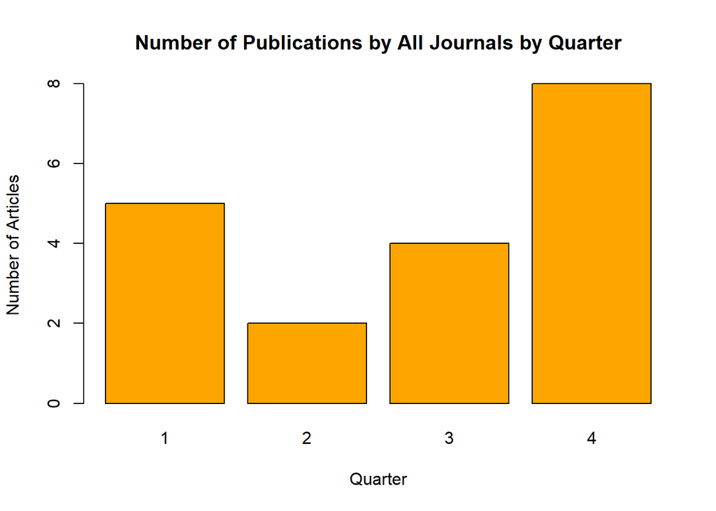

```r
df <- dbGetQuery(dbcon, "SELECT COUNT(*) AS number_article, quarter(pubmed) AS quarter
FROM fact_article
JOIN dim_history ON fact_article.history_id = dim_history.history_id
GROUP BY quarter
ORDER BY quarter ASC;")

barplot(c(5, 2, 4, 8),
        names.arg = c("1", "2", "3", "4"),
        xlab="Quarter",
        ylab="Number of Articles",
        main="Number of Publications by All Journals by Quarter",
        col = "orange")
```

## graph for query2: how many articles all journals has published by year

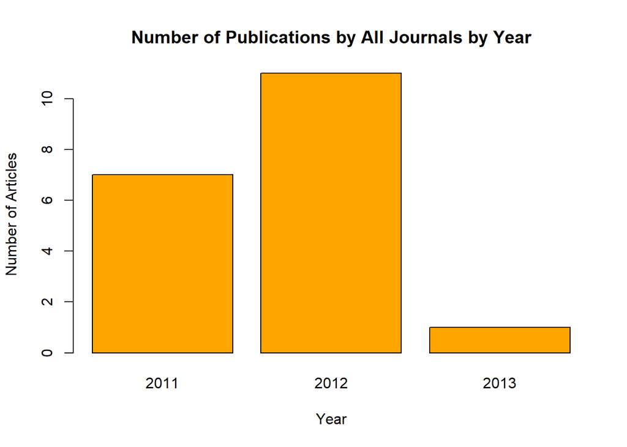

```r
df <- dbGetQuery(dbcon, "SELECT year(pubmed) AS year, COUNT(*) AS number_article
FROM fact_article
JOIN dim_history ON fact_article.history_id = dim_history.history_id
GROUP BY year
ORDER BY year ASC;")

barplot(c(7, 11, 1),
        xlab="Year",
        ylab="Number of Articles",
        names.arg = c("2011", "2012", "2013"),
        main="Number of Publications by All Journals by Year",
        col = "orange")
```

## graph for query3: top 3 authors with most publications

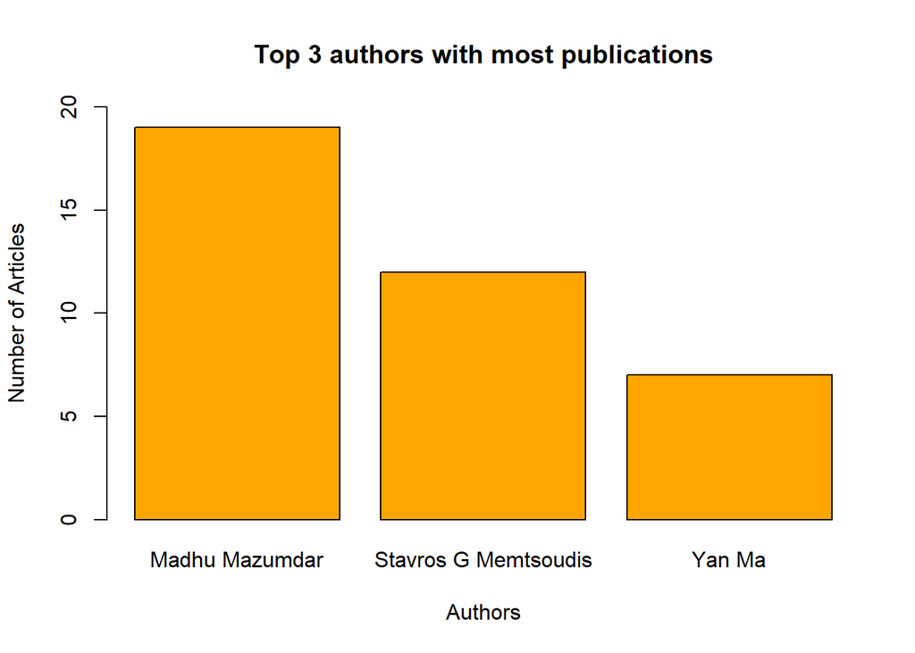

```r
df <- dbGetQuery(dbcon, "SELECT number_of_articles, author
FROM fact_summary
WHERE year IS NULL AND quarter IS NULL AND journal_title IS NULL
ORDER BY number_of_articles DESC
LIMIT 3;")

author1 <- df$author[1]
author2 <- df$author[2]
author3 <- df$author[3]
authors <- c(author1, author2, author3)

barplot(t(as.matrix(df$number_of_articles)),
        xlab="Authors",
        ylab="Number of Articles",
        ylim=c(0,20),
        names.arg = authors,
        main="Top 3 authors with most publications",
        col = "orange")
```

## query4: the average number of months between submission and publication.

```sql
   SELECT
    AVG((SUBSTRING(j.pub_date, 1, 4) - SUBSTRING(h.received, 1, 4)) * 12 + SUBSTRING(j.pub_date, 5, 2) - SUBSTRING(h.received, 5, 2) + 1) as average_months
   FROM dim_history AS h
   JOIN fact_article AS f ON f.fact_article_id = h.history_id
   JOIN dim_journal AS j ON j.journal_id = f.journal_id;
```

1 records

| average_months |
| --- |
| 10.8 |

## query5: number of quarterly publications from 2012 ~ 2013

```sql
DROP TABLE IF EXISTS author_temp;
```

```sql
CREATE TABLE author_temp
   SELECT SUBSTRING_INDEX(a.authors_names, ';', -1) AS name, a.authors_id AS ids, j.journal_title AS title,
    SUBSTRING(j.pub_date,1, 4) + 0 AS year, SUBSTRING(j.pub_date,5, 2) + 0 AS quarter
   FROM dim_authors a
   JOIN fact_article e
   JOIN dim_journal j
   ON a.authors_id = e.authors_id AND j.journal_id = e.journal_id;
```

```sql
UPDATE author_temp
SET quarter = 1
WHERE quarter <=3 ;
```

```sql
UPDATE author_temp
SET quarter = 2
WHERE quarter >= 4
AND quarter <= 6;
```

```sql
UPDATE author_temp
SET quarter = 3
WHERE quarter >= 7
AND quarter <= 9;
```

```sql
UPDATE author_temp
SET quarter = 4
WHERE quarter >= 10
AND quarter <= 12;
```

```sql
  SELECT DISTINCT year, quarter, GROUP_CONCAT(name) as name, GROUP_CONCAT(title) as title, COUNT(title) AS number_of_articles
  FROM author_temp
  group by year, quarter;
```

5 records

| year | quarter | name | title | number_of_articles |
| --- | --- | --- | --- | --- |
| 2012 | 1 | Gregory A Liguori,David Polsky,Stavros G Memtsoudis,Shahrokh F Shariat,Stavros G Memtsoudis | Journal of clinical anesthesia,PloS one,Regional anesthesia and pain medicine,BJU international,Spine | 5 |
| 2012 | 2 | José G Guillem,Madhu Mazumdar,Federico P Girardi,Iman Osman | Diseases of the colon and rectum,The Journal of arthroplasty,Spine,Cancer | 4 |
| 2012 | 3 | Stavros G Memtsoudis,Madhu Mazumdar,Paula W Brill,Madhu Mazumdar | HSS journal : the musculoskeletal journal of Hospital for Special Surgery,Anesthesiology,Pediatric radiology,Journal of intensive care medicine | 4 |
| 2012 | 4 | Pina C Sanelli,Stavros G Memtsoudis,Stavros G Memtsoudis | Stroke; a journal of cerebral circulation,Regional anesthesia and pain medicine,The Journal of arthroplasty | 3 |
| 2013 | 1 | Stavros G Memtsoudis,Theodore H Schwartz,Madhu Mazumdar | Psychosomatics,Seizure : the journal of the British Epilepsy Association,Clinical orthopaedics and related research | 3 |

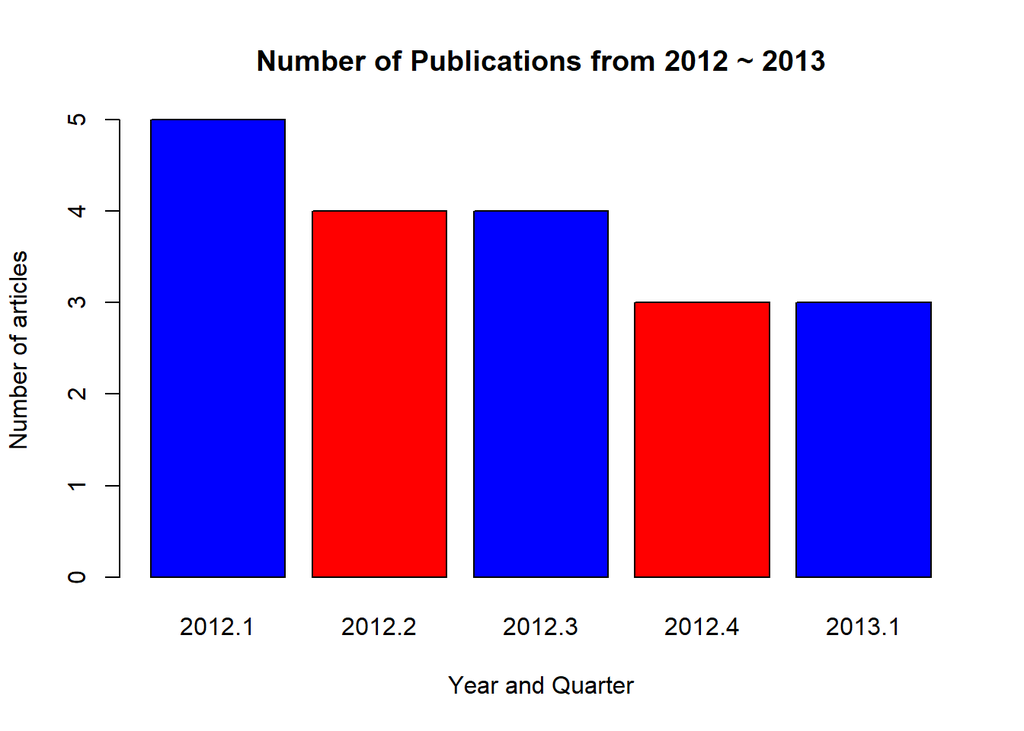

```r
year_quarter <- c(5,4,4,3,3)
colours = c("blue","red")
barplot(year_quarter, names.arg = c('2012.1', '2012.2','2012.3','2012.4','2013.1'), main="Number of Publications from 2012 ~ 2013", ylab = "Number of articles", xlab="Year and Quarter", col = colours)
```

## *********************Disconnect database***********************

```r
dbDisconnect(dbcon)
```

## References

### [1] Jack Thomas. CS5200 Database Management Systems, Module: XML stores & XPath. 2022 Fall.